# Project Stage - III - Kevin Hayes

### Notes:

The distrabutions look similar to each other, but NC and MO are bimodal.

For most of them, the gamma distrabution fits well.

Florida has more neutral skew while the others are more right skewed. This means that florida had more values that are higher than the other states

### Model a poission distribution of COVID-19 cases and deaths of a state and compare to other 5 states. Describe how the poission modeling is different from the first modeling you did. (25 points)

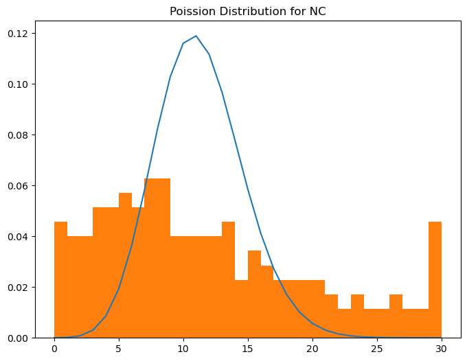

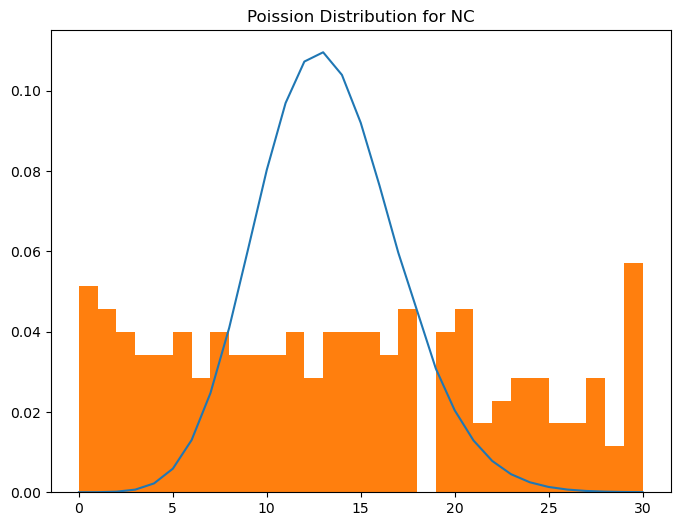

```python
def make_poission(state, dataset):
    dates = get_state_dates(dataset, state)
    population = combined[combined["State"] == state]["population"].sum()
    dates /= population
    dates *= 100000
    date_sum = dates.sum()



    #Normalise for population

    mean, median, mode, variance, skewness, kurtosis, max_val, min_val, stv = get_stats(dates)
    #got how to make poisson distrabution from https://docs.scipy.org/doc/scipy/reference/generated/scipy.stats.poisson.html

    #Break into bins and work off of those.

    #Splitting into 30 bins
    bin_num = 30

    step = (max_val - min_val)/bin_num

    bins = [[0]] * bin_num

    def get_bin(num):
        return (num - min_val) // step

    bin_map = date_sum.map(get_bin)
    #print(bin_map)
    mu = bin_map.mean()

    #Used chatGPT to tell me to use linspace.

    x_range = np.linspace(0, 30, 30)

    #Histogram
    plt.figure(figsize = (8,6))
    #plt.hist(date_sum, bins = 30, density = True, label = "Histogram %s"%name)
    plt.title('Poission Distribution for %s'%state)
    #Poission distrabutuin
    plt.plot(bin_map, stats.poisson.pmf(bin_map, mu))
    plt.hist(bin_map, density = True, bins = bin_num)
make_poission("NC", cases)
make_poission("NC", deaths)
```

```
CASES:
```

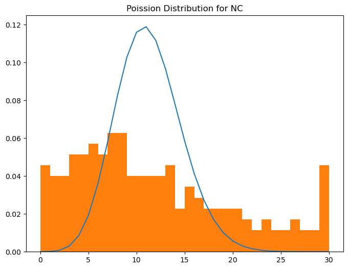

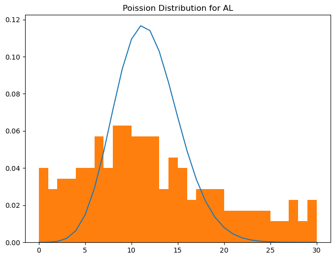

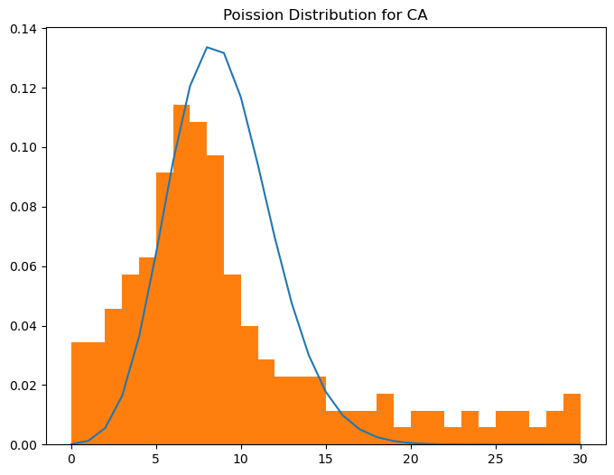

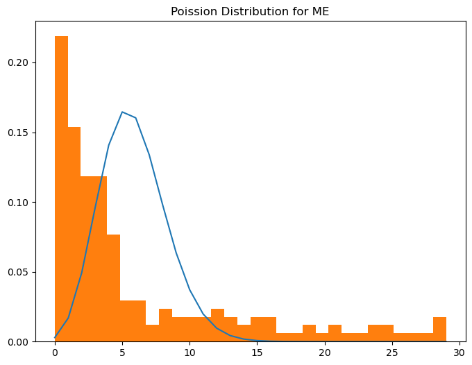

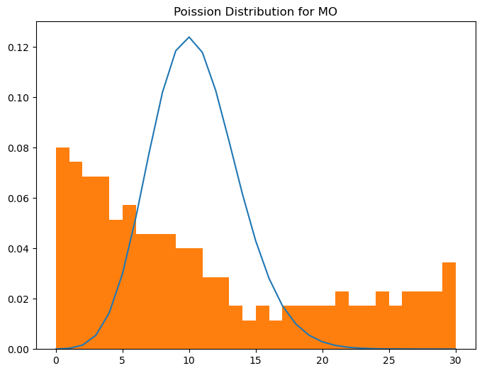

```python
#Make case maps

print("CASES:")

for i in ["NC", "AL", "CA", "ME", "MO"]:
    make_poission(i, cases)
```

```
DEATHS:
```

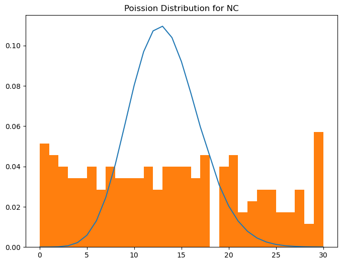

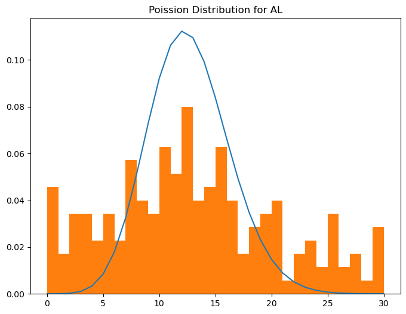

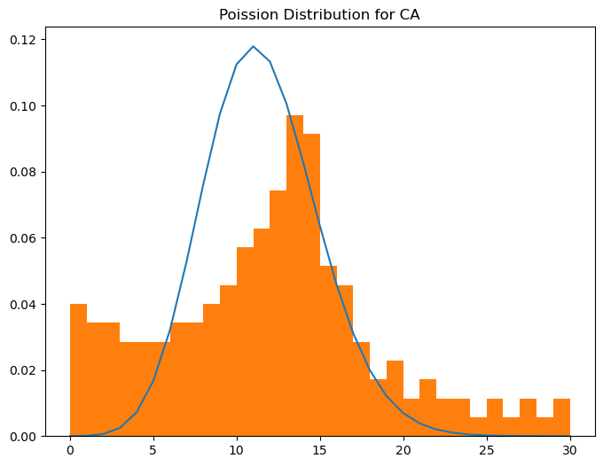

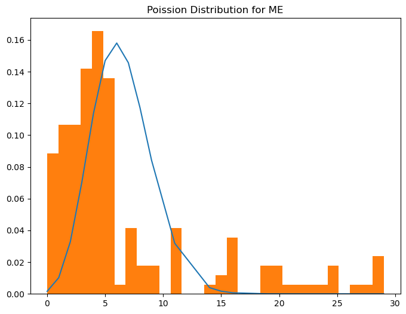

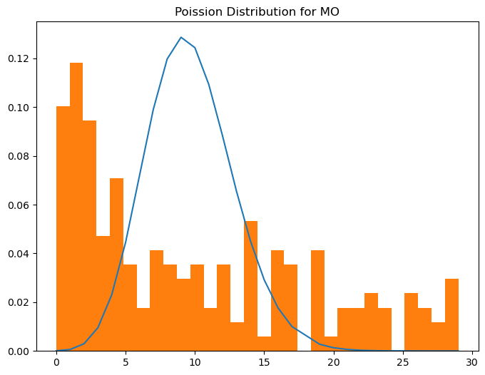

```python
#Make death map

print("DEATHS:")

for i in ["NC", "AL", "CA", "ME", "MO"]:
    make_poission(i, deaths)
```

### Poission modeling forced me to put my data into bins to work with, rather than working with the data inately. To do otherwise caused either a flat line or a line with a large spike in it at mu.

### Perform corelation between Enrichment data variables and COVID-19 cases to observe any patterns. (20 points)

You can compare either within your chosen specific state or among different states with the different enrichment variables. Within the state you can compare the county based covid data to enrichment data for correlation. Between states you would need to aggregate to state level data and then perform correlation. Both covid and enrichment data will need to be normalized for population. For number of covid cases you can use a measure of center value (median or mean) to compare the number of cases.

```python
#Get data

demographic_data = pd.read_csv("./Stage_1_Deliverables_Kevin_Hayes/Task_3/Merged_Housing_Data.csv")

demographic_data
```

|  | Unnamed: 0.1 | Unnamed: 0 | countyFIPS | County Name_deaths | State | StateFIPS_deaths | 2020-01-22_deaths | 2020-01-23_deaths | 2020-01-24_deaths | 2020-01-25_deaths | ... | DP05_0087PM | DP05_0088PE | DP05_0088PM | DP05_0089PE | DP05_0089PM | DP05_0090PE | DP05_0090PM | DP05_0091PE | DP05_0091PM | Unnamed: 366 |
| --- | --- | --- | --- | --- | --- | --- | --- | --- | --- | --- | --- | --- | --- | --- | --- | --- | --- | --- | --- | --- | --- |
| 0 | 0 | 2 | 1003 | Baldwin County | AL | 1 | 0 | 0 | 0 | 0 | ... | 0.9 | (X) | (X) | 189876 | (X) | 48.1 | 0.4 | 51.9 | 0.4 | NaN |
| 1 | 1 | 8 | 1015 | Calhoun County | AL | 1 | 0 | 0 | 0 | 0 | ... | 0.8 | (X) | (X) | 90642 | (X) | 47.8 | 0.3 | 52.2 | 0.3 | NaN |
| 2 | 2 | 22 | 1043 | Cullman County | AL | 1 | 0 | 0 | 0 | 0 | ... | 0.6 | (X) | (X) | 69096 | (X) | 49.0 | 0.6 | 51.0 | 0.6 | NaN |
| 3 | 3 | 25 | 1049 | DeKalb County | AL | 1 | 0 | 0 | 0 | 0 | ... | 0.6 | (X) | (X) | 52110 | (X) | 49.6 | 0.9 | 50.4 | 0.9 | NaN |
| 4 | 4 | 26 | 1051 | Elmore County | AL | 1 | 0 | 0 | 0 | 0 | ... | 1.4 | (X) | (X) | 69952 | (X) | 47.8 | 0.5 | 52.2 | 0.5 | NaN |
| ... | ... | ... | ... | ... | ... | ... | ... | ... | ... | ... | ... | ... | ... | ... | ... | ... | ... | ... | ... | ... | ... |
| 809 | 809 | 3164 | 55133 | Waukesha County | WI | 55 | 0 | 0 | 0 | 0 | ... | 0.4 | (X) | (X) | 317977 | (X) | 49.5 | 0.2 | 50.5 | 0.2 | NaN |
| 810 | 810 | 3167 | 55139 | Winnebago County | WI | 55 | 0 | 0 | 0 | 0 | ... | 0.6 | (X) | (X) | 134656 | (X) | 50.6 | 0.4 | 49.4 | 0.4 | NaN |
| 811 | 811 | 3168 | 55141 | Wood County | WI | 55 | 0 | 0 | 0 | 0 | ... | 0.6 | (X) | (X) | 56907 | (X) | 50.2 | 0.7 | 49.8 | 0.7 | NaN |
| 812 | 812 | 3180 | 56021 | Laramie County | WY | 56 | 0 | 0 | 0 | 0 | ... | 0.7 | (X) | (X) | 77414 | (X) | 50.6 | 0.7 | 49.4 | 0.7 | NaN |
| 813 | 813 | 3182 | 56025 | Natrona County | WY | 56 | 0 | 0 | 0 | 0 | ... | 1.0 | (X) | (X) | 60269 | (X) | 50.0 | 1.1 | 50.0 | 1.1 | NaN |

814 rows × 2908 columns

#### Note: Have to convert all (X) data to 0 to make sum work

```python
#Convert to state level data:
demographic_data = demographic_data.applymap(lambda x : 0 if ((x == "(X)") or (x == "*" in x) or (x == "N") )else x)
demographic_data.dropna(axis = 1, inplace = True)

#Drop all non-int or float variables



drop_vals = demographic_data.drop(columns=["Unnamed: 0.1", "Unnamed: 0", "countyFIPS", "County Name_deaths", "County Name_cases", "County Name", "State Full Name", "Merge_Key", "NAME"])

#print([(i, type(i) != int) for i in drop_vals["DP05_0005M"].values])

#Remove all non-numbers aside from state
state_save = drop_vals["State"]
fix_dtypes = drop_vals.select_dtypes(include=[np.number]) #Got from https://stackoverflow.com/questions/48817592/how-to-drop-dataframe-columns-based-on-dtype
fix_dtypes["State"] = state_save


group = fix_dtypes.groupby("State")

statewide_df = group.sum()
print(len(statewide_df))

#print(drop_columns)
print(statewide_df)
```

```
49
       StateFIPS_deaths  2020-01-22_deaths  2020-01-23_deaths  \
State
AK                    4                  0                  0
AL                   20                  0                  0
AR                   55                  0                  0
AZ                   40                  0                  0
CA                  252                715                726
CO                   88                  0                  0
DE                   30                  0                  0
FL                  492                  0                  0
GA                  507                  0                  0
HI                   60                  0                  0
IA                  190                  0                  0
ID                   96                  0                  0
IL                  374                  0                  0
IN                  486                  0                  0
KS                  160                  0                  0
KY                  294                  0                  0
LA                  374                  0                  0
MA                  300                  0                  0
MD                  360                  0                  0
ME                  138                  0                  0
MI                  780                  0                  0
MN                  432                  0                  0
MO                  435                  0                  0
MS                  308                  0                  0
MT                  180                  0                  0
NC                 1554                  0                  0
ND                  152                  0                  0
NE                   93                  0                  0
NH                  198                  0                  0
NJ                  714                  0                  0
NM                  315                  0                  0
NV                   64                  0                  0
NY                 1368                  0                  0
OH                 1482                  0                  0
OK                  440                  0                  0
OR                  615                  0                  0
PA                 1638                  0                  0
```

[output cut: 259 more lines]

```
PA          1975.2         14.1
RI           206.5          2.2
SC          1096.7          9.6
SD           149.0          2.0
TN          1085.6         10.8
TX          2777.5         37.7
UT           348.0          3.4
VA          1130.5         14.1
VT            51.4          0.5
WA           997.7         13.2
WI          1252.8         12.5
WV           357.9          3.9
WY            99.4          1.8

[49 rows x 2660 columns]
```

### TODO: Drop deaths, find mean of all covid cases, normalize and preform corrilation

```python
#Drop deaths

drop_lables = []

for i in statewide_df.columns:
    if "_death" in i:
        drop_lables.append(i)

if drop_lables != []:
    statewide_df.drop(labels =drop_lables , inplace = True, axis = 1)
'''
with pd.option_context('display.max_columns', 9999):
    display(statewide_df.head())
'''

#Get mean of cases
mean = statewide_df.loc[:, "2020-01-22_cases":"2023-07-23_cases"].mean(axis = 1)
'''
#Drop redundent case info
drop_lables = []
for i in statewide_df.columns:
    if "_case" in i:
        drop_lables.append(i)
if drop_lables != []:
    statewide_df.drop(labels =drop_lables , inplace = True, axis = 1)
'''
statewide_df["mean_value"] = mean

statewide_df
```

| State | StateFIPS_cases | 2020-01-22_cases | 2020-01-23_cases | 2020-01-24_cases | 2020-01-25_cases | 2020-01-26_cases | 2020-01-27_cases | 2020-01-28_cases | 2020-01-29_cases | 2020-01-30_cases | ... | DP05_0078PE | DP05_0088PE | DP05_0088PM | DP05_0089PE | DP05_0089PM | DP05_0090PE | DP05_0090PM | DP05_0091PE | DP05_0091PM | mean_value |
| --- | --- | --- | --- | --- | --- | --- | --- | --- | --- | --- | --- | --- | --- | --- | --- | --- | --- | --- | --- | --- | --- |
| AK | 4 | 0 | 0 | 0 | 0 | 0 | 0 | 0 | 0 | 0 | ... | 185.6 | 0 | 0 | 153543 | 0 | 108.6 | 2.0 | 91.4 | 2.0 | 213.556522 |
| AL | 20 | 0 | 0 | 0 | 0 | 0 | 0 | 0 | 0 | 0 | ... | 1886.3 | 0 | 0 | 2869484 | 0 | 955.2 | 9.5 | 1044.8 | 9.5 | 8594.101186 |
| AR | 55 | 0 | 0 | 0 | 0 | 0 | 0 | 0 | 0 | 0 | ... | 1006.1 | 0 | 0 | 1292454 | 0 | 532.6 | 7.0 | 567.4 | 7.0 | 3569.658498 |
| AZ | 40 | 0 | 0 | 0 | 0 | 0 | 0 | 0 | 0 | 0 | ... | 727.4 | 0 | 0 | 5205230 | 0 | 500.7 | 4.7 | 499.3 | 4.7 | 18305.913043 |
| CA | 252 | 0 | 0 | 0 | 0 | 0 | 0 | 0 | 0 | 0 | ... | 2649.3 | 0 | 0 | 25779638 | 0 | 2080.1 | 26.7 | 2119.9 | 26.7 | 61712.475099 |
| CO | 88 | 0 | 0 | 0 | 0 | 0 | 0 | 0 | 0 | 0 | ... | 845.7 | 0 | 0 | 3689754 | 0 | 551.3 | 3.8 | 548.7 | 3.8 | 6830.223715 |
| DE | 30 | 0 | 0 | 0 | 0 | 0 | 0 | 0 | 0 | 0 | ... | 270.9 | 0 | 0 | 769749 | 0 | 143.1 | 1.1 | 156.9 | 1.1 | 1960.052964 |
| FL | 492 | 0 | 0 | 0 | 0 | 0 | 0 | 0 | 0 | 0 | ... | 3363.4 | 0 | 0 | 15648882 | 0 | 1992.5 | 18.7 | 2107.5 | 18.7 | 27127.289328 |
| GA | 507 | 0 | 0 | 0 | 0 | 0 | 0 | 0 | 0 | 0 | ... | 3513.7 | 0 | 0 | 6079593 | 0 | 1854.0 | 23.0 | 2046.0 | 23.0 | 15709.735968 |
| HI | 60 | 0 | 0 | 0 | 0 | 0 | 0 | 0 | 0 | 0 | ... | 352.1 | 0 | 0 | 1057200 | 0 | 200.8 | 2.4 | 199.2 | 2.4 | 852.415810 |
| IA | 190 | 0 | 0 | 0 | 0 | 0 | 0 | 0 | 0 | 0 | ... | 926.1 | 0 | 0 | 1250032 | 0 | 496.9 | 6.2 | 503.1 | 6.2 | 2594.997628 |
| ID | 96 | 0 | 0 | 0 | 0 | 0 | 0 | 0 | 0 | 0 | ... | 516.7 | 0 | 0 | 929193 | 0 | 296.8 | 3.2 | 303.2 | 3.2 | 1955.074308 |
| IL | 374 | 0 | 0 | 0 | 0 | 0 | 0 | 0 | 0 | 0 | ... | 1935.4 | 0 | 0 | 7664486 | 0 | 1074.7 | 9.8 | 1125.3 | 9.8 | 18242.420553 |
| IN | 486 | 0 | 0 | 0 | 0 | 0 | 0 | 0 | 0 | 0 | ... | 2519.9 | 0 | 0 | 3719111 | 0 | 1318.2 | 14.5 | 1381.8 | 14.5 | 10557.249802 |
| KS | 160 | 0 | 0 | 0 | 0 | 0 | 0 | 0 | 0 | 0 | ... | 701.1 | 0 | 0 | 1329670 | 0 | 404.7 | 6.4 | 395.3 | 6.4 | 2662.835573 |
| KY | 294 | 0 | 0 | 0 | 0 | 0 | 0 | 0 | 0 | 0 | ... | 1333.6 | 0 | 0 | 1721549 | 0 | 690.7 | 6.8 | 709.3 | 6.8 | 4014.679842 |
| LA | 374 | 0 | 0 | 0 | 0 | 0 | 0 | 0 | 0 | 0 | ... | 1607.0 | 0 | 0 | 2521282 | 0 | 813.3 | 7.4 | 886.7 | 7.4 | 8105.464822 |
| MA | 300 | 0 | 0 | 0 | 0 | 0 | 0 | 0 | 0 | 0 | ... | 1062.0 | 0 | 0 | 5113753 | 0 | 577.2 | 4.6 | 622.8 | 4.6 | 16077.939921 |
| MD | 360 | 0 | 0 | 0 | 0 | 0 | 0 | 0 | 0 | 0 | ... | 1373.8 | 0 | 0 | 3760380 | 0 | 734.4 | 7.1 | 765.6 | 7.1 | 8143.038735 |
| ME | 138 | 0 | 0 | 0 | 0 | 0 | 0 | 0 | 0 | 0 | ... | 587.5 | 0 | 0 | 789520 | 0 | 293.7 | 2.8 | 306.3 | 2.8 | 1023.666403 |
| MI | 780 | 0 | 0 | 0 | 0 | 0 | 0 | 0 | 0 | 0 | ... | 2825.1 | 0 | 0 | 6530643 | 0 | 1487.0 | 13.4 | 1513.0 | 13.4 | 20795.790514 |
| MN | 432 | 0 | 0 | 0 | 0 | 0 | 0 | 0 | 0 | 0 | ... | 1516.9 | 0 | 0 | 3089007 | 0 | 800.8 | 9.6 | 799.2 | 9.6 | 5630.257708 |
| MO | 435 | 0 | 0 | 0 | 0 | 0 | 0 | 0 | 0 | 0 | ... | 1431.9 | 0 | 0 | 2460878 | 0 | 736.1 | 7.0 | 763.9 | 7.0 | 5653.946245 |
| MS | 308 | 0 | 0 | 0 | 0 | 0 | 0 | 0 | 0 | 0 | ... | 1056.5 | 0 | 0 | 1052542 | 0 | 517.8 | 4.3 | 582.2 | 4.3 | 3089.766798 |
| MT | 180 | 0 | 0 | 0 | 0 | 0 | 0 | 0 | 0 | 0 | ... | 571.9 | 0 | 0 | 536653 | 0 | 302.1 | 3.2 | 297.9 | 3.2 | 1041.576285 |
| NC | 1554 | 0 | 0 | 0 | 0 | 0 | 0 | 0 | 0 | 0 | ... | 3769.4 | 0 | 0 | 6540742 | 0 | 2024.7 | 24.4 | 2175.3 | 24.4 | 12083.386561 |
| ND | 152 | 0 | 0 | 0 | 0 | 0 | 0 | 0 | 0 | 0 | ... | 381.6 | 0 | 0 | 323662 | 0 | 204.1 | 3.3 | 195.9 | 3.3 | 679.323320 |
| NE | 93 | 0 | 0 | 0 | 0 | 0 | 0 | 0 | 0 | 0 | ... | 266.7 | 0 | 0 | 792234 | 0 | 149.7 | 1.1 | 150.3 | 1.1 | 703.800791 |
| NH | 198 | 0 | 0 | 0 | 0 | 0 | 0 | 0 | 0 | 0 | ... | 577.1 | 0 | 0 | 953429 | 0 | 297.1 | 3.3 | 302.9 | 3.3 | 1353.723320 |
| NJ | 714 | 0 | 0 | 0 | 0 | 0 | 0 | 0 | 0 | 0 | ... | 1693.0 | 0 | 0 | 6453101 | 0 | 1021.1 | 11.2 | 1078.9 | 11.2 | 25442.646640 |
| NM | 315 | 0 | 0 | 0 | 0 | 0 | 0 | 0 | 0 | 0 | ... | 487.3 | 0 | 0 | 1181464 | 0 | 448.2 | 8.0 | 451.8 | 8.0 | 3698.539921 |
| NV | 64 | 0 | 0 | 0 | 0 | 0 | 0 | 0 | 0 | 0 | ... | 141.2 | 0 | 0 | 1953315 | 0 | 100.0 | 0.7 | 100.0 | 0.7 | 6179.554941 |
| NY | 1368 | 0 | 0 | 0 | 0 | 0 | 0 | 0 | 0 | 0 | ... | 3359.2 | 0 | 0 | 13248716 | 0 | 1867.5 | 18.7 | 1932.5 | 18.7 | 51121.831621 |
| OH | 1482 | 0 | 0 | 0 | 0 | 0 | 0 | 0 | 0 | 0 | ... | 3658.0 | 0 | 0 | 7480311 | 0 | 1877.5 | 17.5 | 1922.5 | 17.5 | 19143.666403 |
| OK | 440 | 0 | 0 | 0 | 0 | 0 | 0 | 0 | 0 | 0 | ... | 991.2 | 0 | 0 | 1839420 | 0 | 539.8 | 4.8 | 560.2 | 4.8 | 4702.108300 |
| OR | 615 | 0 | 0 | 0 | 0 | 0 | 0 | 0 | 0 | 0 | ... | 1285.1 | 0 | 0 | 2824449 | 0 | 740.5 | 8.9 | 759.5 | 8.9 | 3459.053755 |
| PA | 1638 | 0 | 0 | 0 | 0 | 0 | 0 | 0 | 0 | 0 | ... | 3620.4 | 0 | 0 | 9161262 | 0 | 1924.8 | 14.1 | 1975.2 | 14.1 | 27454.558103 |
| RI | 176 | 0 | 0 | 0 | 0 | 0 | 0 | 0 | 0 | 0 | ... | 357.3 | 0 | 0 | 782019 | 0 | 193.5 | 2.2 | 206.5 | 2.2 | 2435.747036 |
| SC | 945 | 0 | 0 | 0 | 0 | 0 | 0 | 0 | 0 | 0 | ... | 1966.9 | 0 | 0 | 3471461 | 0 | 1003.3 | 9.6 | 1096.7 | 9.6 | 9025.512253 |
| SD | 138 | 0 | 0 | 0 | 0 | 0 | 0 | 0 | 0 | 0 | ... | 284.9 | 0 | 0 | 287157 | 0 | 151.0 | 2.0 | 149.0 | 2.0 | 652.254545 |
| TN | 987 | 0 | 0 | 0 | 0 | 0 | 0 | 0 | 0 | 0 | ... | 1958.4 | 0 | 0 | 3669162 | 0 | 1014.4 | 10.8 | 1085.6 | 10.8 | 9270.793676 |
| TX | 2640 | 0 | 0 | 0 | 0 | 0 | 0 | 0 | 0 | 0 | ... | 3541.7 | 0 | 0 | 17449750 | 0 | 2722.5 | 37.7 | 2777.5 | 37.7 | 46139.699605 |
| UT | 343 | 0 | 0 | 0 | 0 | 0 | 0 | 0 | 0 | 0 | ... | 599.0 | 0 | 0 | 1990070 | 0 | 352.0 | 3.4 | 348.0 | 3.4 | 2367.055336 |
| VA | 1122 | 0 | 0 | 0 | 0 | 0 | 0 | 0 | 0 | 0 | ... | 1992.5 | 0 | 0 | 3278551 | 0 | 1069.5 | 14.1 | 1130.5 | 14.1 | 5539.700395 |
| VT | 50 | 0 | 0 | 0 | 0 | 0 | 0 | 0 | 0 | 0 | ... | 97.3 | 0 | 0 | 137263 | 0 | 48.6 | 0.5 | 51.4 | 0.5 | 124.147036 |
| WA | 1060 | 0 | 0 | 0 | 0 | 0 | 0 | 0 | 0 | 0 | ... | 1630.3 | 0 | 0 | 5215684 | 0 | 1002.3 | 13.2 | 997.7 | 13.2 | 7760.347036 |
| WI | 1375 | 1 | 1 | 1 | 1 | 1 | 1 | 1 | 1 | 1 | ... | 2334.1 | 0 | 0 | 3497285 | 0 | 1247.2 | 12.5 | 1252.8 | 12.5 | 7139.041897 |
| WV | 378 | 0 | 0 | 0 | 0 | 0 | 0 | 0 | 0 | 0 | ... | 684.3 | 0 | 0 | 572668 | 0 | 342.1 | 3.9 | 357.9 | 3.9 | 1555.808696 |
| WY | 112 | 0 | 0 | 0 | 0 | 0 | 0 | 0 | 0 | 0 | ... | 174.6 | 0 | 0 | 137683 | 0 | 100.6 | 1.8 | 99.4 | 1.8 | 346.211067 |

49 rows × 1395 columns

```python
#Normalize for population

population = statewide_df["population"].copy()
#print(population)


statewide_df = statewide_df.div(population, axis = 0)
statewide_df = statewide_df.apply(lambda x : x * 100000)

statewide_df.div(population)

statewide_df
```

| State | StateFIPS_cases | 2020-01-22_cases | 2020-01-23_cases | 2020-01-24_cases | 2020-01-25_cases | 2020-01-26_cases | 2020-01-27_cases | 2020-01-28_cases | 2020-01-29_cases | 2020-01-30_cases | ... | DP05_0078PE | DP05_0088PE | DP05_0088PM | DP05_0089PE | DP05_0089PM | DP05_0090PE | DP05_0090PM | DP05_0091PE | DP05_0091PM | mean_value |
| --- | --- | --- | --- | --- | --- | --- | --- | --- | --- | --- | --- | --- | --- | --- | --- | --- | --- | --- | --- | --- | --- |
| AK | 1.949641 | 0.000000 | 0.000000 | 0.000000 | 0.000000 | 0.000000 | 0.000000 | 0.000000 | 0.000000 | 0.000000 | ... | 90.463332 | 0.0 | 0.0 | 74838.423520 | 0.0 | 52.932747 | 0.974820 | 44.549292 | 0.974820 | 104.089626 |
| AL | 0.552205 | 0.000000 | 0.000000 | 0.000000 | 0.000000 | 0.000000 | 0.000000 | 0.000000 | 0.000000 | 0.000000 | ... | 52.081219 | 0.0 | 0.0 | 79227.177986 | 0.0 | 26.373313 | 0.262297 | 28.847192 | 0.262297 | 237.285304 |
| AR | 3.206784 | 0.000000 | 0.000000 | 0.000000 | 0.000000 | 0.000000 | 0.000000 | 0.000000 | 0.000000 | 0.000000 | ... | 58.660824 | 0.0 | 0.0 | 75356.740135 | 0.0 | 31.053329 | 0.408136 | 33.082349 | 0.408136 | 208.129518 |
| AZ | 0.562686 | 0.000000 | 0.000000 | 0.000000 | 0.000000 | 0.000000 | 0.000000 | 0.000000 | 0.000000 | 0.000000 | ... | 10.232448 | 0.0 | 0.0 | 73222.776749 | 0.0 | 7.043424 | 0.066116 | 7.023730 | 0.066116 | 257.512115 |
| CA | 0.644065 | 0.000000 | 0.000000 | 0.000000 | 0.000000 | 0.000000 | 0.000000 | 0.000000 | 0.000000 | 0.000000 | ... | 6.771119 | 0.0 | 0.0 | 65887.971343 | 0.0 | 5.316350 | 0.068240 | 5.418071 | 0.068240 | 157.725636 |
| CO | 1.801108 | 0.000000 | 0.000000 | 0.000000 | 0.000000 | 0.000000 | 0.000000 | 0.000000 | 0.000000 | 0.000000 | ... | 17.309058 | 0.0 | 0.0 | 75518.703792 | 0.0 | 11.283533 | 0.077775 | 11.230319 | 0.077775 | 139.795130 |
| DE | 3.080829 | 0.000000 | 0.000000 | 0.000000 | 0.000000 | 0.000000 | 0.000000 | 0.000000 | 0.000000 | 0.000000 | ... | 27.819882 | 0.0 | 0.0 | 79048.824972 | 0.0 | 14.695553 | 0.112964 | 16.112734 | 0.112964 | 201.286242 |
| FL | 2.362597 | 0.000000 | 0.000000 | 0.000000 | 0.000000 | 0.000000 | 0.000000 | 0.000000 | 0.000000 | 0.000000 | ... | 16.151139 | 0.0 | 0.0 | 75146.358589 | 0.0 | 9.568039 | 0.089798 | 10.120273 | 0.089798 | 130.265984 |
| GA | 6.130669 | 0.000000 | 0.000000 | 0.000000 | 0.000000 | 0.000000 | 0.000000 | 0.000000 | 0.000000 | 0.000000 | ... | 42.487833 | 0.0 | 0.0 | 73514.736641 | 0.0 | 22.418659 | 0.278117 | 24.740332 | 0.278117 | 189.962898 |
| HI | 4.237929 | 0.000000 | 0.000000 | 0.000000 | 0.000000 | 0.000000 | 0.000000 | 0.000000 | 0.000000 | 0.000000 | ... | 24.869578 | 0.0 | 0.0 | 74672.302170 | 0.0 | 14.182934 | 0.169517 | 14.069923 | 0.169517 | 60.207956 |
| IA | 11.470853 | 0.000000 | 0.000000 | 0.000000 | 0.000000 | 0.000000 | 0.000000 | 0.000000 | 0.000000 | 0.000000 | ... | 55.911353 | 0.0 | 0.0 | 75468.071182 | 0.0 | 29.999300 | 0.374312 | 30.373612 | 0.374312 | 156.667562 |
| ID | 8.198954 | 0.000000 | 0.000000 | 0.000000 | 0.000000 | 0.000000 | 0.000000 | 0.000000 | 0.000000 | 0.000000 | ... | 44.129164 | 0.0 | 0.0 | 79358.448894 | 0.0 | 25.348434 | 0.273298 | 25.895031 | 0.273298 | 166.974638 |
| IL | 3.452301 | 0.000000 | 0.000000 | 0.000000 | 0.000000 | 0.000000 | 0.000000 | 0.000000 | 0.000000 | 0.000000 | ... | 17.865197 | 0.0 | 0.0 | 70748.966571 | 0.0 | 9.920289 | 0.090461 | 10.387365 | 0.090461 | 168.391253 |
| IN | 9.750388 | 0.000000 | 0.000000 | 0.000000 | 0.000000 | 0.000000 | 0.000000 | 0.000000 | 0.000000 | 0.000000 | ... | 50.555561 | 0.0 | 0.0 | 74614.764375 | 0.0 | 26.446423 | 0.290907 | 27.722400 | 0.290907 | 211.805108 |
| KS | 8.859814 | 0.000000 | 0.000000 | 0.000000 | 0.000000 | 0.000000 | 0.000000 | 0.000000 | 0.000000 | 0.000000 | ... | 38.822597 | 0.0 | 0.0 | 73628.929950 | 0.0 | 22.409792 | 0.354393 | 21.889278 | 0.354393 | 147.451423 |
| KY | 12.941525 | 0.000000 | 0.000000 | 0.000000 | 0.000000 | 0.000000 | 0.000000 | 0.000000 | 0.000000 | 0.000000 | ... | 58.703462 | 0.0 | 0.0 | 75780.508215 | 0.0 | 30.403780 | 0.299328 | 31.222530 | 0.299328 | 176.721359 |
| LA | 11.054326 | 0.000000 | 0.000000 | 0.000000 | 0.000000 | 0.000000 | 0.000000 | 0.000000 | 0.000000 | 0.000000 | ... | 47.498131 | 0.0 | 0.0 | 74521.582684 | 0.0 | 24.038724 | 0.218722 | 26.208210 | 0.218722 | 239.573386 |
| MA | 4.370775 | 0.000000 | 0.000000 | 0.000000 | 0.000000 | 0.000000 | 0.000000 | 0.000000 | 0.000000 | 0.000000 | ... | 15.472542 | 0.0 | 0.0 | 74503.538288 | 0.0 | 8.409370 | 0.067019 | 9.073728 | 0.067019 | 234.243502 |
| MD | 6.959258 | 0.000000 | 0.000000 | 0.000000 | 0.000000 | 0.000000 | 0.000000 | 0.000000 | 0.000000 | 0.000000 | ... | 26.557303 | 0.0 | 0.0 | 72692.933356 | 0.0 | 14.196887 | 0.137252 | 14.800023 | 0.137252 | 157.415307 |
| ME | 14.489315 | 0.000000 | 0.000000 | 0.000000 | 0.000000 | 0.000000 | 0.000000 | 0.000000 | 0.000000 | 0.000000 | ... | 61.684582 | 0.0 | 0.0 | 82895.679034 | 0.0 | 30.837041 | 0.293986 | 32.159979 | 0.293986 | 107.479889 |
| MI | 9.085802 | 0.000000 | 0.000000 | 0.000000 | 0.000000 | 0.000000 | 0.000000 | 0.000000 | 0.000000 | 0.000000 | ... | 32.908075 | 0.0 | 0.0 | 76071.958618 | 0.0 | 17.321266 | 0.156089 | 17.624126 | 0.156089 | 242.239013 |
| MN | 10.443352 | 0.000000 | 0.000000 | 0.000000 | 0.000000 | 0.000000 | 0.000000 | 0.000000 | 0.000000 | 0.000000 | ... | 36.670186 | 0.0 | 0.0 | 74674.968809 | 0.0 | 19.358880 | 0.232074 | 19.320201 | 0.232074 | 136.108244 |
| MO | 13.683170 | 0.000000 | 0.000000 | 0.000000 | 0.000000 | 0.000000 | 0.000000 | 0.000000 | 0.000000 | 0.000000 | ... | 45.041219 | 0.0 | 0.0 | 77408.300745 | 0.0 | 23.154439 | 0.220189 | 24.028904 | 0.220189 | 177.848057 |
| MS | 22.064238 | 0.000000 | 0.000000 | 0.000000 | 0.000000 | 0.000000 | 0.000000 | 0.000000 | 0.000000 | 0.000000 | ... | 75.684636 | 0.0 | 0.0 | 75401.096335 | 0.0 | 37.093710 | 0.308040 | 41.707142 | 0.308040 | 221.342050 |
| MT | 27.694949 | 0.000000 | 0.000000 | 0.000000 | 0.000000 | 0.000000 | 0.000000 | 0.000000 | 0.000000 | 0.000000 | ... | 87.993009 | 0.0 | 0.0 | 82569.875896 | 0.0 | 46.481357 | 0.492355 | 45.835141 | 0.492355 | 160.257791 |
| NC | 18.004255 | 0.000000 | 0.000000 | 0.000000 | 0.000000 | 0.000000 | 0.000000 | 0.000000 | 0.000000 | 0.000000 | ... | 43.671325 | 0.0 | 0.0 | 75779.399448 | 0.0 | 23.457667 | 0.282692 | 25.202481 | 0.282692 | 139.995092 |
| ND | 36.658218 | 0.000000 | 0.000000 | 0.000000 | 0.000000 | 0.000000 | 0.000000 | 0.000000 | 0.000000 | 0.000000 | ... | 92.031420 | 0.0 | 0.0 | 78058.368565 | 0.0 | 49.223304 | 0.795869 | 47.245690 | 0.795869 | 163.834093 |
| NE | 8.630185 | 0.000000 | 0.000000 | 0.000000 | 0.000000 | 0.000000 | 0.000000 | 0.000000 | 0.000000 | 0.000000 | ... | 24.749145 | 0.0 | 0.0 | 73517.487261 | 0.0 | 13.891815 | 0.102077 | 13.947493 | 0.102077 | 65.311089 |
| NH | 16.854090 | 0.000000 | 0.000000 | 0.000000 | 0.000000 | 0.000000 | 0.000000 | 0.000000 | 0.000000 | 0.000000 | ... | 49.123715 | 0.0 | 0.0 | 81157.467426 | 0.0 | 25.289648 | 0.280902 | 25.783353 | 0.280902 | 115.231188 |
| NJ | 8.038558 | 0.000000 | 0.000000 | 0.000000 | 0.000000 | 0.000000 | 0.000000 | 0.000000 | 0.000000 | 0.000000 | ... | 19.060615 | 0.0 | 0.0 | 72652.138718 | 0.0 | 11.496039 | 0.126095 | 12.146779 | 0.126095 | 286.445647 |
| NM | 19.626229 | 0.000000 | 0.000000 | 0.000000 | 0.000000 | 0.000000 | 0.000000 | 0.000000 | 0.000000 | 0.000000 | ... | 30.361465 | 0.0 | 0.0 | 73611.693494 | 0.0 | 27.925321 | 0.498444 | 28.149620 | 0.498444 | 230.439342 |
| NV | 2.337273 | 0.000000 | 0.000000 | 0.000000 | 0.000000 | 0.000000 | 0.000000 | 0.000000 | 0.000000 | 0.000000 | ... | 5.156608 | 0.0 | 0.0 | 71334.845744 | 0.0 | 3.651989 | 0.025564 | 3.651989 | 0.025564 | 225.676657 |
| NY | 7.433443 | 0.000000 | 0.000000 | 0.000000 | 0.000000 | 0.000000 | 0.000000 | 0.000000 | 0.000000 | 0.000000 | ... | 18.253232 | 0.0 | 0.0 | 71990.917289 | 0.0 | 10.147628 | 0.101612 | 10.500825 | 0.101612 | 277.785980 |
| OH | 15.181762 | 0.000000 | 0.000000 | 0.000000 | 0.000000 | 0.000000 | 0.000000 | 0.000000 | 0.000000 | 0.000000 | ... | 37.472931 | 0.0 | 0.0 | 76629.081392 | 0.0 | 19.233305 | 0.179272 | 19.694289 | 0.179272 | 196.109703 |
| OK | 17.815943 | 0.000000 | 0.000000 | 0.000000 | 0.000000 | 0.000000 | 0.000000 | 0.000000 | 0.000000 | 0.000000 | ... | 40.134462 | 0.0 | 0.0 | 74479.551751 | 0.0 | 21.856923 | 0.194356 | 22.682935 | 0.194356 | 190.392036 |
| OR | 16.435953 | 0.000000 | 0.000000 | 0.000000 | 0.000000 | 0.000000 | 0.000000 | 0.000000 | 0.000000 | 0.000000 | ... | 34.344461 | 0.0 | 0.0 | 75483.758205 | 0.0 | 19.789957 | 0.237854 | 20.297734 | 0.237854 | 92.443651 |
| PA | 13.902385 | 0.000000 | 0.000000 | 0.000000 | 0.000000 | 0.000000 | 0.000000 | 0.000000 | 0.000000 | 0.000000 | ... | 30.727836 | 0.0 | 0.0 | 77755.428529 | 0.0 | 16.336576 | 0.119673 | 16.764341 | 0.119673 | 233.018216 |
| RI | 17.410539 | 0.000000 | 0.000000 | 0.000000 | 0.000000 | 0.000000 | 0.000000 | 0.000000 | 0.000000 | 0.000000 | ... | 35.345372 | 0.0 | 0.0 | 77360.067743 | 0.0 | 19.141700 | 0.217632 | 20.427706 | 0.217632 | 240.952657 |
| SC | 21.472119 | 0.000000 | 0.000000 | 0.000000 | 0.000000 | 0.000000 | 0.000000 | 0.000000 | 0.000000 | 0.000000 | ... | 44.691547 | 0.0 | 0.0 | 78877.910211 | 0.0 | 22.796801 | 0.218129 | 24.919019 | 0.218129 | 205.076060 |
| SD | 37.496230 | 0.000000 | 0.000000 | 0.000000 | 0.000000 | 0.000000 | 0.000000 | 0.000000 | 0.000000 | 0.000000 | ... | 77.410695 | 0.0 | 0.0 | 78023.948679 | 0.0 | 41.028484 | 0.543424 | 40.485060 | 0.543424 | 177.225264 |
| TN | 20.693394 | 0.000000 | 0.000000 | 0.000000 | 0.000000 | 0.000000 | 0.000000 | 0.000000 | 0.000000 | 0.000000 | ... | 41.059720 | 0.0 | 0.0 | 76927.473322 | 0.0 | 21.267861 | 0.226432 | 22.760637 | 0.226432 | 194.371013 |
| TX | 10.341444 | 0.000000 | 0.000000 | 0.000000 | 0.000000 | 0.000000 | 0.000000 | 0.000000 | 0.000000 | 0.000000 | ... | 13.873595 | 0.0 | 0.0 | 68354.398150 | 0.0 | 10.664614 | 0.147679 | 10.880061 | 0.147679 | 180.739059 |
| UT | 12.291836 | 0.000000 | 0.000000 | 0.000000 | 0.000000 | 0.000000 | 0.000000 | 0.000000 | 0.000000 | 0.000000 | ... | 21.465918 | 0.0 | 0.0 | 71316.659918 | 0.0 | 12.614362 | 0.121843 | 12.471017 | 0.121843 | 84.826403 |
| VA | 24.886640 | 0.000000 | 0.000000 | 0.000000 | 0.000000 | 0.000000 | 0.000000 | 0.000000 | 0.000000 | 0.000000 | ... | 44.194858 | 0.0 | 0.0 | 72720.249541 | 0.0 | 23.722159 | 0.312747 | 25.075176 | 0.312747 | 122.873914 |
| VT | 30.529877 | 0.000000 | 0.000000 | 0.000000 | 0.000000 | 0.000000 | 0.000000 | 0.000000 | 0.000000 | 0.000000 | ... | 59.411140 | 0.0 | 0.0 | 83812.448862 | 0.0 | 29.675040 | 0.305299 | 31.384713 | 0.305299 | 75.803873 |
| WA | 14.861833 | 0.000000 | 0.000000 | 0.000000 | 0.000000 | 0.000000 | 0.000000 | 0.000000 | 0.000000 | 0.000000 | ... | 22.857779 | 0.0 | 0.0 | 73127.002492 | 0.0 | 14.052844 | 0.185072 | 13.988349 | 0.185072 | 108.804697 |
| WI | 30.077352 | 0.021874 | 0.021874 | 0.021874 | 0.021874 | 0.021874 | 0.021874 | 0.021874 | 0.021874 | 0.021874 | ... | 51.057126 | 0.0 | 0.0 | 76501.144252 | 0.0 | 27.281799 | 0.273430 | 27.404296 | 0.273430 | 156.162530 |
| WV | 52.573969 | 0.000000 | 0.000000 | 0.000000 | 0.000000 | 0.000000 | 0.000000 | 0.000000 | 0.000000 | 0.000000 | ... | 95.175573 | 0.0 | 0.0 | 79649.284340 | 0.0 | 47.580832 | 0.542430 | 49.778369 | 0.542430 | 216.388988 |
| WY | 62.444943 | 0.000000 | 0.000000 | 0.000000 | 0.000000 | 0.000000 | 0.000000 | 0.000000 | 0.000000 | 0.000000 | ... | 97.347205 | 0.0 | 0.0 | 76764.348398 | 0.0 | 56.088939 | 1.003579 | 55.419886 | 1.003579 | 193.027948 |

49 rows × 1395 columns

```python
#Drop redundent case info
drop_lables = []
for i in statewide_df.columns:
    if "_cases" in i:
        drop_lables.append(i)
if drop_lables != []:
    statewide_df.drop(labels =drop_lables , inplace = True, axis = 1)
statewide_df
```

| State | population | DP05_0001E | DP05_0002E | DP05_0003E | DP05_0004E | DP05_0005E | DP05_0006E | DP05_0006M | DP05_0007E | DP05_0007M | ... | DP05_0078PE | DP05_0088PE | DP05_0088PM | DP05_0089PE | DP05_0089PM | DP05_0090PE | DP05_0090PM | DP05_0091PE | DP05_0091PM | mean_value |
| --- | --- | --- | --- | --- | --- | --- | --- | --- | --- | --- | --- | --- | --- | --- | --- | --- | --- | --- | --- | --- | --- |
| AK | 100000.0 | 101713.246834 | 54711.794352 | 47001.452482 | 114.346432 | 6610.744470 | 6807.170779 | 884.649503 | 7101.566536 | 777.906671 | ... | 90.463332 | 0.0 | 0.0 | 74838.423520 | 0.0 | 52.932747 | 0.974820 | 44.549292 | 0.974820 | 104.089626 |
| AL | 100000.0 | 104506.959578 | 50619.228940 | 53887.730639 | 52.418065 | 5956.332177 | 6513.976448 | 772.866190 | 6474.410956 | 779.685922 | ... | 52.081219 | 0.0 | 0.0 | 79227.177986 | 0.0 | 26.373313 | 0.262297 | 28.847192 | 0.262297 | 237.285304 |
| AR | 100000.0 | 103344.442410 | 50605.324194 | 52739.118216 | 61.873438 | 6203.785871 | 6956.913651 | 964.134163 | 6841.119599 | 1015.967452 | ... | 58.660824 | 0.0 | 0.0 | 75356.740135 | 0.0 | 31.053329 | 0.408136 | 33.082349 | 0.408136 | 208.129518 |
| AZ | 100000.0 | 101169.979341 | 50556.398178 | 50613.581163 | 14.169845 | 5404.150767 | 6021.009577 | 312.276772 | 6362.841442 | 314.246174 | ... | 10.232448 | 0.0 | 0.0 | 73222.776749 | 0.0 | 7.043424 | 0.066116 | 7.023730 | 0.066116 | 257.512115 |
| CA | 100000.0 | 98754.551618 | 49412.355640 | 49342.195978 | 10.822341 | 5368.927854 | 5793.609651 | 275.644589 | 6459.332864 | 275.304665 | ... | 6.771119 | 0.0 | 0.0 | 65887.971343 | 0.0 | 5.316350 | 0.068240 | 5.418071 | 0.068240 | 157.725636 |
| CO | 100000.0 | 101556.607703 | 51312.854325 | 50243.753378 | 22.861793 | 5462.699562 | 5724.249117 | 447.657239 | 6296.571693 | 444.321096 | ... | 17.309058 | 0.0 | 0.0 | 75518.703792 | 0.0 | 11.283533 | 0.077775 | 11.230319 | 0.077775 | 139.795130 |
| DE | 100000.0 | 104583.451432 | 50798.448084 | 53785.003348 | 29.052214 | 5551.447784 | 5906.770018 | 540.171951 | 6151.901282 | 536.372263 | ... | 27.819882 | 0.0 | 0.0 | 79048.824972 | 0.0 | 14.695553 | 0.112964 | 16.112734 | 0.112964 | 201.286242 |
| FL | 100000.0 | 103704.754458 | 50931.473246 | 52773.281213 | 19.170173 | 5128.142579 | 5424.768607 | 452.077256 | 5861.882746 | 455.981304 | ... | 16.151139 | 0.0 | 0.0 | 75146.358589 | 0.0 | 9.568039 | 0.089798 | 10.120273 | 0.089798 | 130.265984 |
| GA | 100000.0 | 103189.689061 | 50098.785995 | 53090.903067 | 44.660774 | 5983.012848 | 6466.537612 | 796.055864 | 7122.265247 | 801.823771 | ... | 42.487833 | 0.0 | 0.0 | 73514.736641 | 0.0 | 22.418659 | 0.278117 | 24.740332 | 0.278117 | 189.962898 |
| HI | 100000.0 | 101719.327638 | 51225.326426 | 50494.001212 | 28.507133 | 5574.783195 | 5808.293061 | 423.015908 | 6234.840576 | 421.885793 | ... | 24.869578 | 0.0 | 0.0 | 74672.302170 | 0.0 | 14.182934 | 0.169517 | 14.069923 | 0.169517 | 60.207956 |
| IA | 100000.0 | 102389.439087 | 51216.091554 | 51173.347533 | 60.892118 | 5893.362119 | 6722.342566 | 799.820330 | 6538.084440 | 799.276974 | ... | 55.911353 | 0.0 | 0.0 | 75468.071182 | 0.0 | 29.999300 | 0.374312 | 30.373612 | 0.374312 | 156.667562 |
| ID | 100000.0 | 108145.832070 | 54151.873675 | 53993.958395 | 50.645625 | 6216.686410 | 7215.592362 | 723.557731 | 7887.735816 | 706.220359 | ... | 44.129164 | 0.0 | 0.0 | 79358.448894 | 0.0 | 25.348434 | 0.273298 | 25.895031 | 0.273298 | 166.974638 |
| IL | 100000.0 | 99460.822567 | 49037.620297 | 50423.202270 | 19.949500 | 5377.355896 | 5804.324312 | 368.814681 | 6447.892315 | 366.470070 | ... | 17.865197 | 0.0 | 0.0 | 70748.966571 | 0.0 | 9.920289 | 0.090461 | 10.387365 | 0.090461 | 168.391253 |
| IN | 100000.0 | 101862.645120 | 50178.205395 | 51684.439725 | 53.101496 | 5999.116848 | 6595.355084 | 744.058934 | 6648.420467 | 730.596979 | ... | 50.555561 | 0.0 | 0.0 | 74614.764375 | 0.0 | 26.446423 | 0.290907 | 27.722400 | 0.290907 | 211.805108 |
| KS | 100000.0 | 101342.427932 | 50699.620745 | 50642.807188 | 45.899374 | 6026.279316 | 6196.443117 | 651.030203 | 7173.126855 | 648.316885 | ... | 38.822597 | 0.0 | 0.0 | 73628.929950 | 0.0 | 22.409792 | 0.354393 | 21.889278 | 0.354393 | 147.451423 |
| KY | 100000.0 | 101514.158425 | 50144.491686 | 51369.666738 | 61.230140 | 6025.028205 | 6351.251476 | 813.379248 | 6306.924552 | 805.279790 | ... | 58.703462 | 0.0 | 0.0 | 75780.508215 | 0.0 | 30.403780 | 0.299328 | 31.222530 | 0.299328 | 176.721359 |
| LA | 100000.0 | 99890.993710 | 48424.684723 | 51466.308987 | 47.702075 | 6014.292001 | 6244.393403 | 881.006097 | 6789.336182 | 850.769266 | ... | 47.498131 | 0.0 | 0.0 | 74521.582684 | 0.0 | 24.038724 | 0.218722 | 26.208210 | 0.218722 | 239.573386 |
| MA | 100000.0 | 101207.980102 | 49565.282763 | 51642.697339 | 16.703643 | 4969.279283 | 5223.920608 | 381.146110 | 5601.016467 | 381.903711 | ... | 15.472542 | 0.0 | 0.0 | 74503.538288 | 0.0 | 8.409370 | 0.067019 | 9.073728 | 0.067019 | 234.243502 |
| MD | 100000.0 | 102699.631643 | 50201.054908 | 52498.576735 | 28.372510 | 5850.281222 | 6308.297079 | 557.977871 | 6580.191438 | 564.782480 | ... | 26.557303 | 0.0 | 0.0 | 72692.933356 | 0.0 | 14.196887 | 0.137252 | 14.800023 | 0.137252 | 157.415307 |
| ME | 100000.0 | 103284.139660 | 50823.896030 | 52460.243630 | 61.401096 | 4738.530867 | 5325.978081 | 728.245554 | 5272.955589 | 711.656339 | ... | 61.684582 | 0.0 | 0.0 | 82895.679034 | 0.0 | 30.837041 | 0.293986 | 32.159979 | 0.293986 | 107.479889 |
| MI | 100000.0 | 100435.489468 | 49601.686604 | 50833.802863 | 34.926754 | 5498.785473 | 5812.490252 | 489.666473 | 6236.505983 | 489.887794 | ... | 32.908075 | 0.0 | 0.0 | 76071.958618 | 0.0 | 17.321266 | 0.156089 | 17.624126 | 0.156089 | 242.239013 |
| MN | 100000.0 | 101367.958201 | 50602.051974 | 50765.906228 | 39.097298 | 5906.609844 | 6536.377796 | 558.743491 | 6521.413827 | 559.758817 | ... | 36.670186 | 0.0 | 0.0 | 74674.968809 | 0.0 | 19.358880 | 0.232074 | 19.320201 | 0.232074 | 136.108244 |
| MO | 100000.0 | 101768.588979 | 49809.159105 | 51959.429874 | 46.230240 | 5619.284524 | 6143.963300 | 643.203334 | 6619.539944 | 654.464425 | ... | 45.041219 | 0.0 | 0.0 | 77408.300745 | 0.0 | 23.154439 | 0.220189 | 24.028904 | 0.220189 | 177.848057 |
| MS | 100000.0 | 100284.041252 | 48022.814996 | 52261.226256 | 72.375000 | 5845.733722 | 6125.476745 | 991.171439 | 7128.611586 | 977.417109 | ... | 75.684636 | 0.0 | 0.0 | 75401.096335 | 0.0 | 37.093710 | 0.308040 | 41.707142 | 0.308040 | 221.342050 |
| MT | 100000.0 | 105588.533060 | 53263.695922 | 52324.837138 | 94.055125 | 5276.041715 | 5982.878367 | 916.395102 | 6663.712539 | 945.936382 | ... | 87.993009 | 0.0 | 0.0 | 82569.875896 | 0.0 | 46.481357 | 0.492355 | 45.835141 | 0.492355 | 160.257791 |
| NC | 100000.0 | 103038.965309 | 50281.551096 | 52757.414214 | 46.793684 | 5794.728553 | 6009.632624 | 721.989162 | 6670.333170 | 722.637964 | ... | 43.671325 | 0.0 | 0.0 | 75779.399448 | 0.0 | 23.457667 | 0.282692 | 25.202481 | 0.282692 | 139.995092 |
| ND | 100000.0 | 104499.313864 | 53690.300766 | 50809.013098 | 101.847140 | 6484.645754 | 6447.022846 | 968.789869 | 6603.061444 | 962.278212 | ... | 92.031420 | 0.0 | 0.0 | 78058.368565 | 0.0 | 49.223304 | 0.795869 | 47.245690 | 0.795869 | 163.834093 |
| NE | 100000.0 | 102786.065127 | 51544.942387 | 51241.122741 | 28.210499 | 6544.186085 | 6863.874137 | 558.920503 | 7302.992818 | 559.106098 | ... | 24.749145 | 0.0 | 0.0 | 73517.487261 | 0.0 | 13.891815 | 0.102077 | 13.947493 | 0.102077 | 65.311089 |
| NH | 100000.0 | 102383.406722 | 51090.025528 | 51293.381194 | 50.579296 | 4747.831313 | 5114.194975 | 603.767996 | 5258.135716 | 584.615620 | ... | 49.123715 | 0.0 | 0.0 | 81157.467426 | 0.0 | 25.289648 | 0.280902 | 25.783353 | 0.280902 | 115.231188 |
| NJ | 100000.0 | 104272.696261 | 51391.650032 | 52881.046228 | 23.105788 | 5779.351714 | 6007.617491 | 499.516448 | 6597.393210 | 497.827675 | ... | 19.060615 | 0.0 | 0.0 | 72652.138718 | 0.0 | 11.496039 | 0.126095 | 12.146779 | 0.126095 | 286.445647 |
| NM | 100000.0 | 100599.254203 | 49852.990196 | 50746.264007 | 55.900486 | 5006.682264 | 5869.114857 | 741.871470 | 6671.858791 | 755.267150 | ... | 30.361465 | 0.0 | 0.0 | 73611.693494 | 0.0 | 27.925321 | 0.498444 | 28.149620 | 0.498444 | 230.439342 |
| NV | 100000.0 | 102976.224822 | 51784.763464 | 51191.461358 | 7.471969 | 5687.497854 | 6264.877290 | 321.849776 | 6562.952618 | 324.406168 | ... | 5.156608 | 0.0 | 0.0 | 71334.845744 | 0.0 | 3.651989 | 0.025564 | 3.651989 | 0.025564 | 225.676657 |
| NY | 100000.0 | 101254.806471 | 49447.556082 | 51807.250389 | 20.427297 | 5474.649243 | 5552.205918 | 367.868486 | 5989.681425 | 369.661641 | ... | 18.253232 | 0.0 | 0.0 | 71990.917289 | 0.0 | 10.147628 | 0.101612 | 10.500825 | 0.101612 | 277.785980 |
| OH | 100000.0 | 100858.814431 | 49705.364212 | 51153.450219 | 38.763688 | 5671.248479 | 5944.305062 | 603.930888 | 6390.077233 | 605.754338 | ... | 37.472931 | 0.0 | 0.0 | 76629.081392 | 0.0 | 19.233305 | 0.179272 | 19.694289 | 0.179272 | 196.109703 |
| OK | 100000.0 | 103355.106576 | 51189.902571 | 52165.204005 | 44.017528 | 6354.825570 | 6798.280599 | 506.863592 | 7175.330749 | 502.935987 | ... | 40.134462 | 0.0 | 0.0 | 74479.551751 | 0.0 | 21.856923 | 0.194356 | 22.682935 | 0.194356 | 190.392036 |
| OR | 100000.0 | 100274.707580 | 50078.024008 | 50196.683572 | 40.312182 | 4772.225751 | 5436.746034 | 576.407539 | 5922.795919 | 592.816767 | ... | 34.344461 | 0.0 | 0.0 | 75483.758205 | 0.0 | 19.789957 | 0.237854 | 20.297734 | 0.237854 | 92.443651 |
| PA | 100000.0 | 101546.398446 | 49975.662339 | 51570.736108 | 32.793672 | 5271.371925 | 5659.272233 | 514.396735 | 5995.280488 | 515.211526 | ... | 30.727836 | 0.0 | 0.0 | 77755.428529 | 0.0 | 16.336576 | 0.119673 | 16.764341 | 0.119673 | 233.018216 |
| RI | 100000.0 | 103214.222827 | 50644.486696 | 52569.736131 | 38.045984 | 4980.601099 | 5099.606087 | 565.446808 | 5638.937087 | 577.614400 | ... | 35.345372 | 0.0 | 0.0 | 77360.067743 | 0.0 | 19.141700 | 0.217632 | 20.427706 | 0.217632 | 240.952657 |
| SC | 100000.0 | 103501.364218 | 50363.594555 | 53137.769663 | 45.214149 | 5540.420299 | 6130.437786 | 730.847324 | 6441.772157 | 731.506257 | ... | 44.691547 | 0.0 | 0.0 | 78877.910211 | 0.0 | 22.796801 | 0.218129 | 24.919019 | 0.218129 | 205.076060 |
| SD | 100000.0 | 105809.741955 | 53822.577621 | 51987.164334 | 83.469869 | 6821.053318 | 6955.822377 | 1077.880757 | 7818.507378 | 1198.520801 | ... | 77.410695 | 0.0 | 0.0 | 78023.948679 | 0.0 | 41.028484 | 0.543424 | 40.485060 | 0.543424 | 177.225264 |
| TN | 100000.0 | 103570.040326 | 50518.865373 | 53051.174953 | 42.575558 | 6129.521779 | 6311.422376 | 722.067377 | 6607.021330 | 723.618857 | ... | 41.059720 | 0.0 | 0.0 | 76927.473322 | 0.0 | 21.267861 | 0.226432 | 22.760637 | 0.226432 | 194.371013 |
| TX | 100000.0 | 104127.007817 | 51938.527167 | 52188.480650 | 21.758163 | 6633.785576 | 7250.499934 | 527.519405 | 7575.797104 | 528.228421 | ... | 13.873595 | 0.0 | 0.0 | 68354.398150 | 0.0 | 10.664614 | 0.147679 | 10.880061 | 0.147679 | 180.739059 |
| UT | 100000.0 | 105573.147176 | 53524.030002 | 52049.117174 | 25.669511 | 7249.173078 | 7924.758195 | 533.530194 | 8619.229019 | 522.241773 | ... | 21.465918 | 0.0 | 0.0 | 71316.659918 | 0.0 | 12.614362 | 0.121843 | 12.471017 | 0.121843 | 84.826403 |
| VA | 100000.0 | 102448.517149 | 50676.497407 | 51772.019742 | 47.326760 | 5789.559722 | 6344.008342 | 666.283238 | 6807.028502 | 682.585984 | ... | 44.194858 | 0.0 | 0.0 | 72720.249541 | 0.0 | 23.722159 | 0.312747 | 25.075176 | 0.312747 | 122.873914 |
| VT | 100000.0 | 103374.772552 | 50286.980839 | 53087.791713 | 57.823586 | 4846.923199 | 3934.079891 | 700.355368 | 5753.660532 | 765.689304 | ... | 59.411140 | 0.0 | 0.0 | 83812.448862 | 0.0 | 29.675040 | 0.305299 | 31.384713 | 0.305299 | 75.803873 |
| WA | 100000.0 | 102289.661604 | 51624.580574 | 50665.081031 | 28.653894 | 5628.288180 | 6118.742678 | 480.471832 | 6251.545771 | 481.004615 | ... | 22.857779 | 0.0 | 0.0 | 73127.002492 | 0.0 | 14.052844 | 0.185072 | 13.988349 | 0.185072 | 108.804697 |
| WI | 100000.0 | 100825.738164 | 50381.512075 | 50444.226089 | 55.451701 | 5373.915083 | 5770.958009 | 640.636669 | 6439.615832 | 623.880849 | ... | 51.057126 | 0.0 | 0.0 | 76501.144252 | 0.0 | 27.281799 | 0.273430 | 27.404296 | 0.273430 | 156.162530 |
| WV | 100000.0 | 100939.377207 | 49914.254361 | 51025.122846 | 95.620644 | 5124.571098 | 5838.353127 | 1046.611413 | 5525.273753 | 1005.303295 | ... | 95.175573 | 0.0 | 0.0 | 79649.284340 | 0.0 | 47.580832 | 0.542430 | 49.778369 | 0.542430 | 216.388988 |
| WY | 100000.0 | 100538.587629 | 51176.975658 | 49361.611972 | 115.578898 | 5315.625732 | 7054.605872 | 1063.794199 | 6627.527069 | 1083.865788 | ... | 97.347205 | 0.0 | 0.0 | 76764.348398 | 0.0 | 56.088939 | 1.003579 | 55.419886 | 1.003579 | 193.027948 |

49 rows × 129 columns

```python
#Find corrilation between mean and values
cor = []
for i in statewide_df.columns:
    cor.append([statewide_df["mean_value"].corr(statewide_df[i]), i])

cor_df = pd.DataFrame(cor).dropna().sort_values(by = 0)
cor_df = cor_df.rename(columns = {0 : "correlation", 1: "Column Name"})

metadata = pd.read_csv("./Demographic_and_Housing_Final/Demographic_And_Housing-Column-Metadata.csv")
#metadata = metadata.rename(columns = {"Column Name" : "index"})

cor_df = cor_df.join(metadata.set_index("Column Name"), on = "Column Name")
cor_df = cor_df.dropna()
cor_df
```

|  | correlation | Column Name | Label |
| --- | --- | --- | --- |
| 15 | -0.383517 | DP05_0011E | Estimate!!SEX AND AGE!!Total population!!35 to... |
| 2 | -0.363958 | DP05_0002E | Estimate!!SEX AND AGE!!Total population!!Male |
| 38 | -0.348666 | DP05_0026E | Estimate!!SEX AND AGE!!Total population!!18 ye... |
| 56 | -0.322049 | DP05_0090E | Estimate!!CITIZEN, VOTING AGE POPULATION!!Citi... |
| 14 | -0.303803 | DP05_0010E | Estimate!!SEX AND AGE!!Total population!!25 to... |
| ... | ... | ... | ... |
| 39 | 0.219174 | DP05_0027E | Estimate!!SEX AND AGE!!Total population!!18 ye... |
| 43 | 0.230168 | DP05_0031E | Estimate!!SEX AND AGE!!Total population!!65 ye... |
| 3 | 0.236060 | DP05_0003E | Estimate!!SEX AND AGE!!Total population!!Female |
| 19 | 0.249471 | DP05_0014E | Estimate!!SEX AND AGE!!Total population!!60 to... |
| 17 | 0.253842 | DP05_0013E | Estimate!!SEX AND AGE!!Total population!!55 to... |

110 rows × 3 columns